## #Logistic regression

title: “logistic regression” author: “sanisaha” date: “November 18, 2018” output: html_document —

```r
library(dplyr)
mydata <- read.table("C:/Users/ratul/Documents/GitHub/IODS-project/data/alc.csv", sep = ",", header = T)
str(mydata)
```

```
## 'data.frame':    382 obs. of  36 variables:
##  $ X         : int  1 2 3 4 5 6 7 8 9 10 ...
##  $ school    : Factor w/ 2 levels "GP","MS": 1 1 1 1 1 1 1 1 1 1 ...
##  $ sex       : Factor w/ 2 levels "F","M": 1 1 1 1 1 2 2 1 2 2 ...
##  $ age       : int  18 17 15 15 16 16 16 17 15 15 ...
##  $ address   : Factor w/ 2 levels "R","U": 2 2 2 2 2 2 2 2 2 2 ...
##  $ famsize   : Factor w/ 2 levels "GT3","LE3": 1 1 2 1 1 2 2 1 2 1 ...
##  $ Pstatus   : Factor w/ 2 levels "A","T": 1 2 2 2 2 2 2 1 1 2 ...
##  $ Medu      : int  4 1 1 4 3 4 2 4 3 3 ...
##  $ Fedu      : int  4 1 1 2 3 3 2 4 2 4 ...
##  $ Mjob      : Factor w/ 5 levels "at_home","health",..: 1 1 1 2 3 4 3 3 4 3 ...
##  $ Fjob      : Factor w/ 5 levels "at_home","health",..: 5 3 3 4 3 3 3 5 3 3 ...
##  $ reason    : Factor w/ 4 levels "course","home",..: 1 1 3 2 2 4 2 2 2 2 ...
##  $ nursery   : Factor w/ 2 levels "no","yes": 2 1 2 2 2 2 2 2 2 2 ...
##  $ internet  : Factor w/ 2 levels "no","yes": 1 2 2 2 1 2 2 1 2 2 ...
```

[output cut: 22 more lines]

```r
dim(mydata)
```

```
## [1] 382  36
```

```r
mydata[1,]
```

```
##   X school sex age address famsize Pstatus Medu Fedu    Mjob    Fjob
## 1 1     GP   F  18       U     GT3       A    4    4 at_home teacher
##   reason nursery internet guardian traveltime studytime failures schoolsup
## 1 course     yes       no   mother          2         2        0       yes
##   famsup paid activities higher romantic famrel freetime goout Dalc Walc
## 1     no   no         no    yes       no      4        3     4    1    1
##   health absences G1 G2 G3 alc_use high_use
## 1      3        5  2  8  8       1    FALSE
```

4.alcohol consumption vs different variables alc_use vs age

```r
attach(mydata)
cor(high_use, age)
```

```
## [1] 0.1130219
```

```r
mytable <- table(high_use, age)
addmargins(mytable)
```

```
##         age
## high_use  15  16  17  18  19  20  22 Sum
##    FALSE  63  79  64  54   7   1   0 268
##    TRUE   18  28  36  27   4   0   1 114
##    Sum    81 107 100  81  11   1   1 382
```

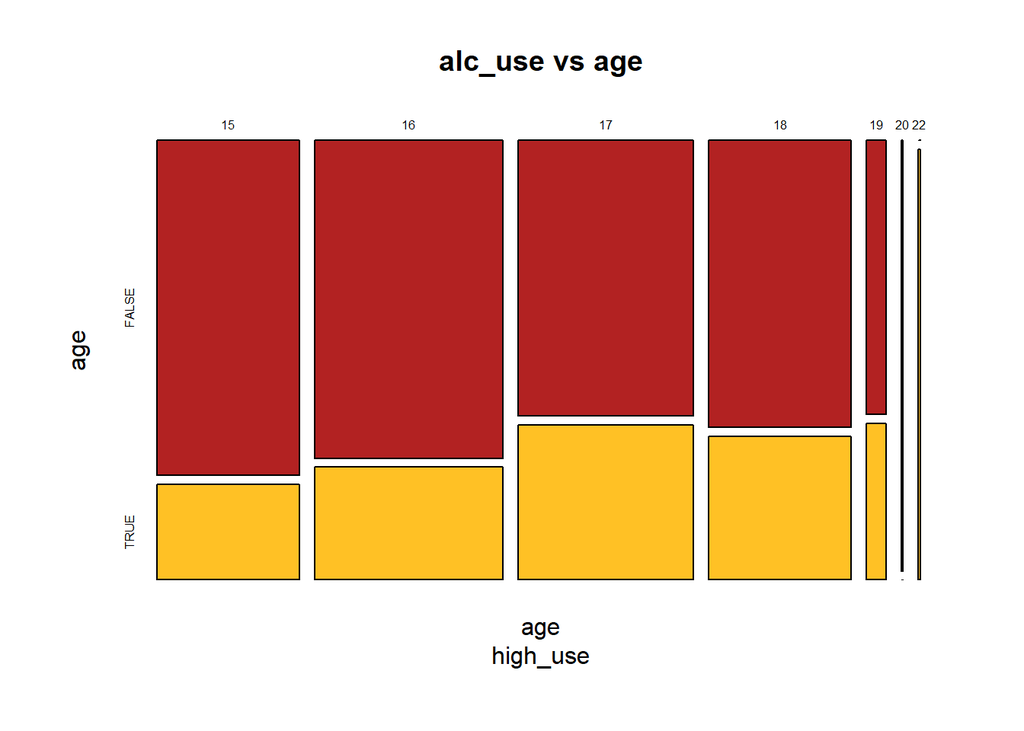

```r
mosaicplot( t(mytable), col = c("firebrick", "goldenrod1"), cex.axis = 0.5, sub = "high_use", ylab = "age", main = "alc_use vs age")
```

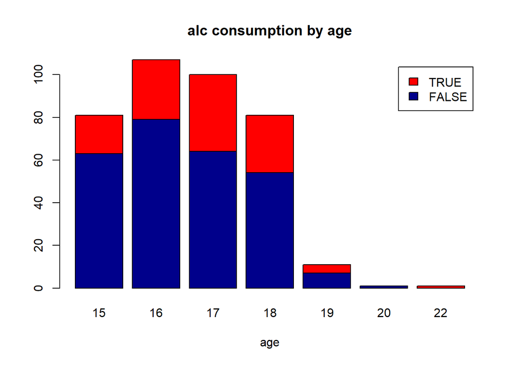

```r
counts <- table(mydata$high_use, mydata$age)
barplot(counts, main="alc consumption by age",
  xlab="age", col=c("darkblue", "red"),
    legend = rownames(counts))

library(ggplot2)
```

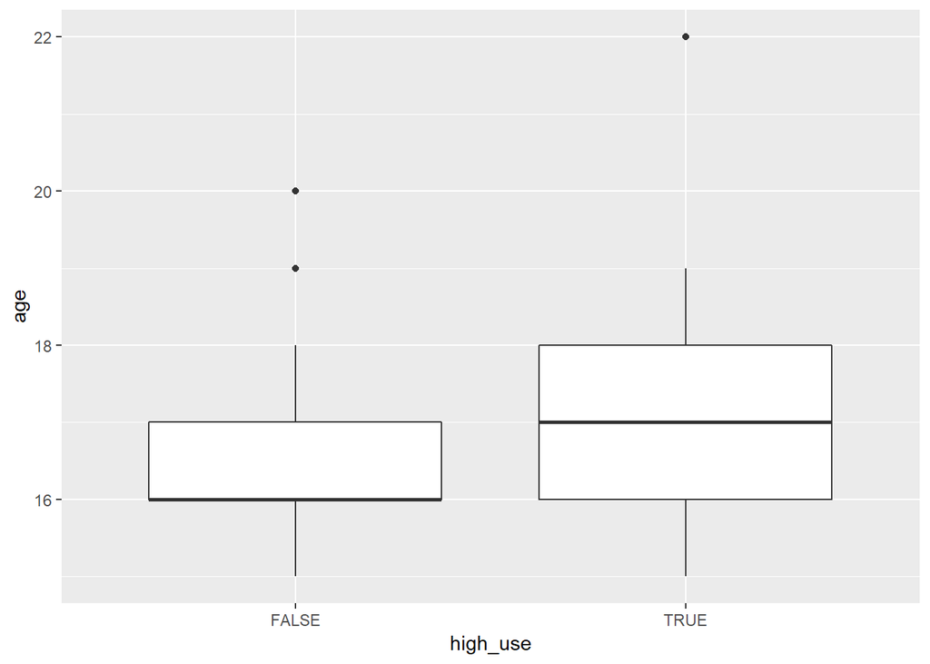

```r
g1 <- ggplot(mydata, aes(x = high_use, y = age))

g1 + geom_boxplot() + ylab("age")
```

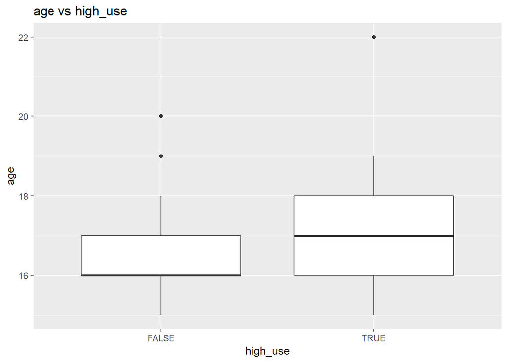

```r
g1 + geom_boxplot() + ggtitle("age vs high_use")
```

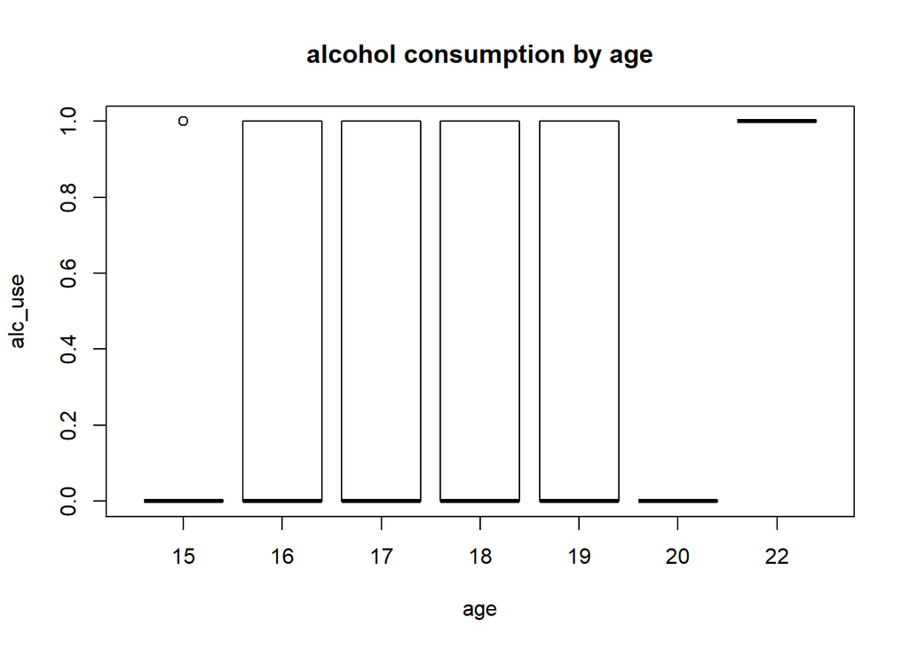

```r
boxplot(high_use ~age, data=mydata, main="alcohol consumption by age",
    xlab="age", ylab="alc_use")
```

alcohol consumption is positively related with age(corelation = 0.11), but there is no strong relationship. from the boxplot we can see that for high alcohol consumption most of the observation(50%) remain at age 16 to 18. while low consumption(50%) 16 to 17 age.

```r
attach(mydata)
cor(failures, high_use)
```

```
## [1] 0.1574346
```

```r
mytable <- table(high_use, failures)
addmargins(mytable)
```

```
##         failures
## high_use   0   1   2   3 Sum
##    FALSE 244  12  10   2 268
##    TRUE   90  12   9   3 114
##    Sum   334  24  19   5 382
```

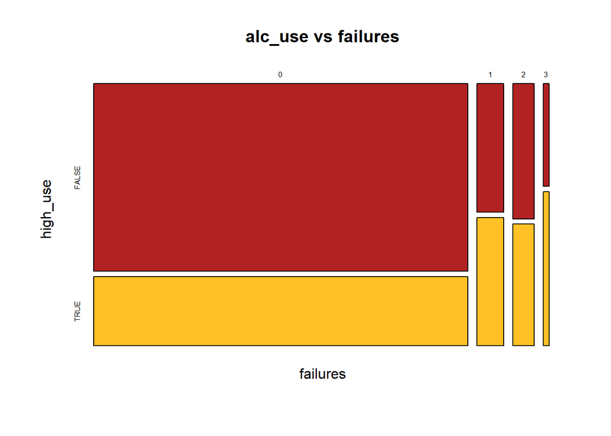

```r
mosaicplot( t(mytable), col = c("firebrick", "goldenrod1"), cex.axis = 0.5, main = "alc_use vs failures")
```

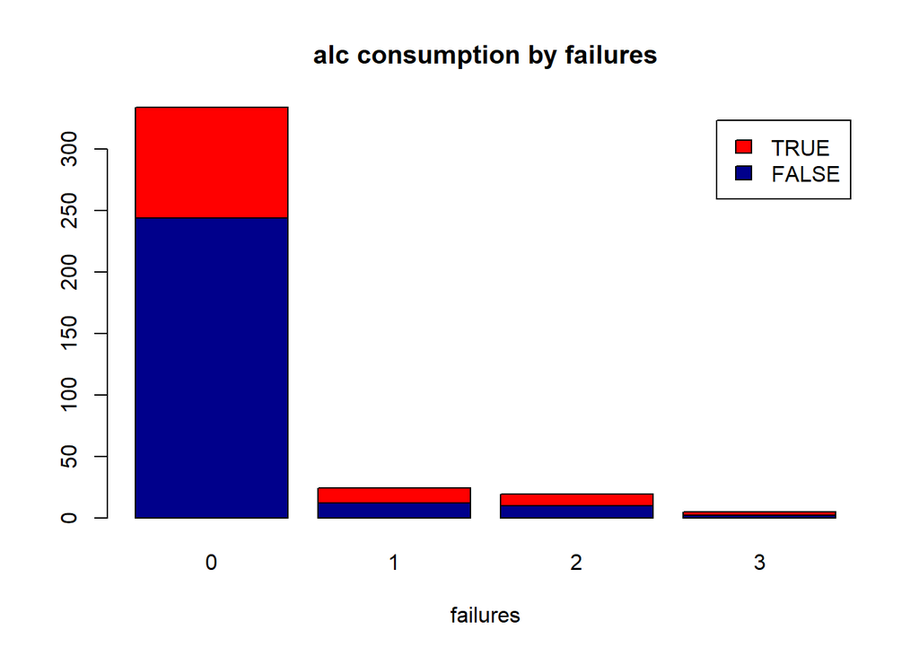

```r
counts <- table(mydata$high_use, mydata$failures)
barplot(counts, main="alc consumption by failures",
  xlab="failures", col=c("darkblue", "red"),
    legend = rownames(counts))
```

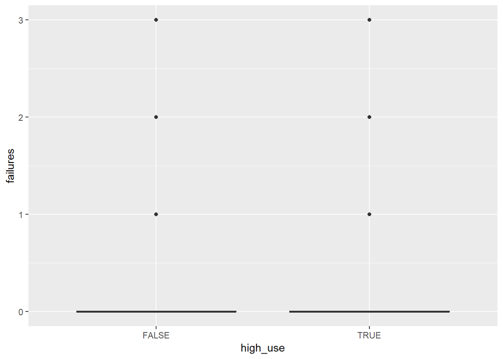

```r
library(ggplot2)
g1 <- ggplot(mydata, aes(x = high_use, y = failures))

g1 + geom_boxplot() + ylab("failures")
```

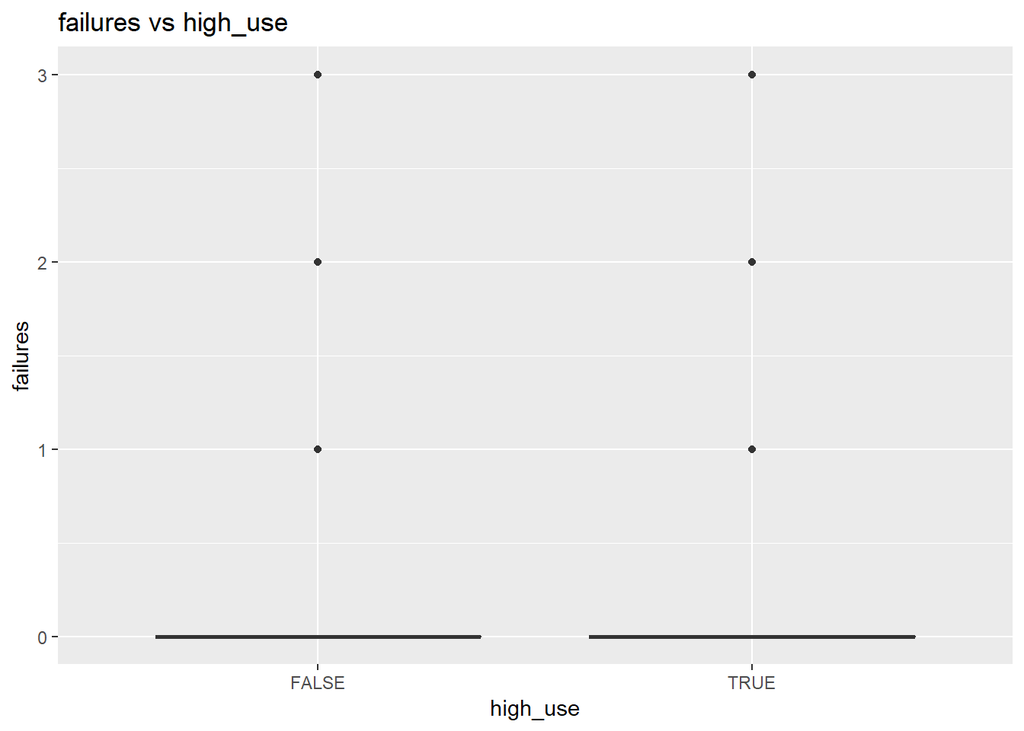

```r
g1 + geom_boxplot() + ggtitle("failures vs high_use")
```

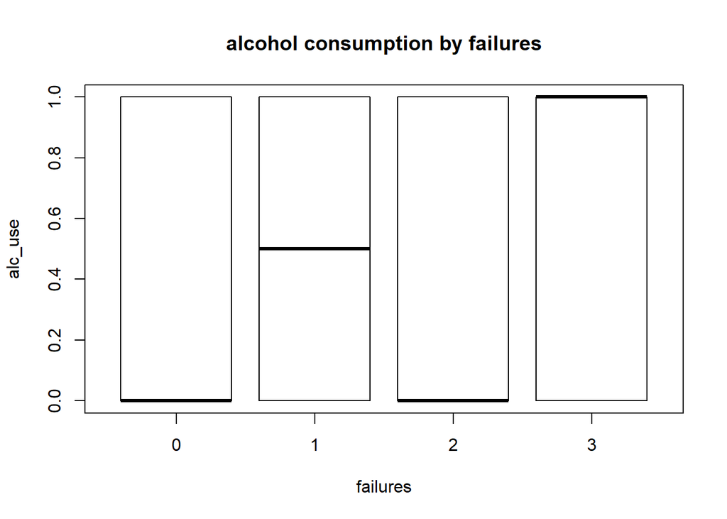

```r
boxplot(high_use ~ failures, data=mydata, main="alcohol consumption by failures",
    xlab="failures", ylab="alc_use")
```

high_use vs health

```r
attach(mydata)
cor(health, high_use)
```

```
## [1] 0.05997391
```

```r
mytable <- table(high_use, health)
addmargins(mytable)
```

```
##         health
## high_use   1   2   3   4   5 Sum
##    FALSE  35  28  62  49  94 268
##    TRUE   11  16  19  18  50 114
##    Sum    46  44  81  67 144 382
```

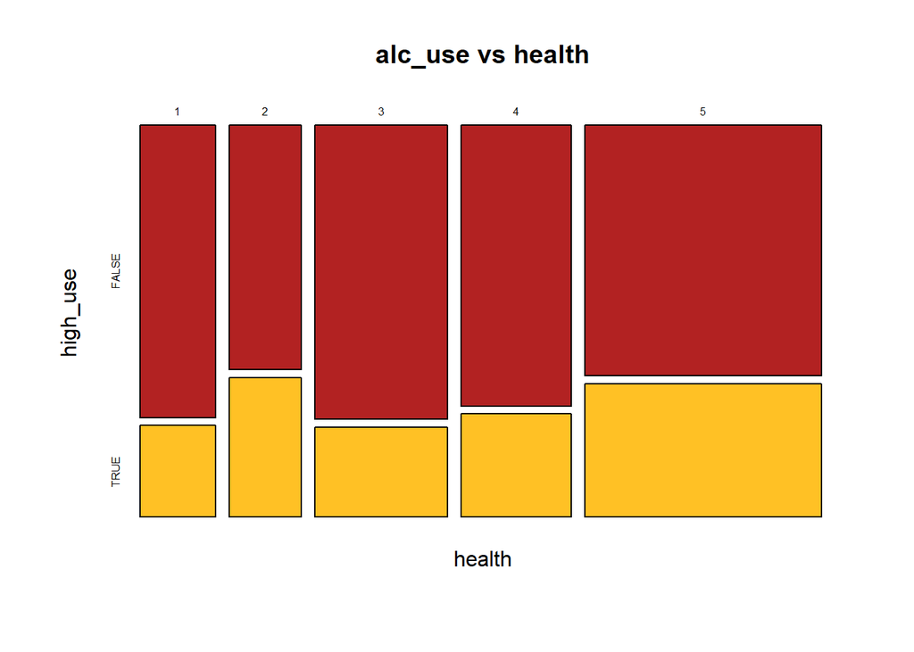

```r
mosaicplot( t(mytable), col = c("firebrick", "goldenrod1"), cex.axis = 0.5, main = "alc_use vs health")
```

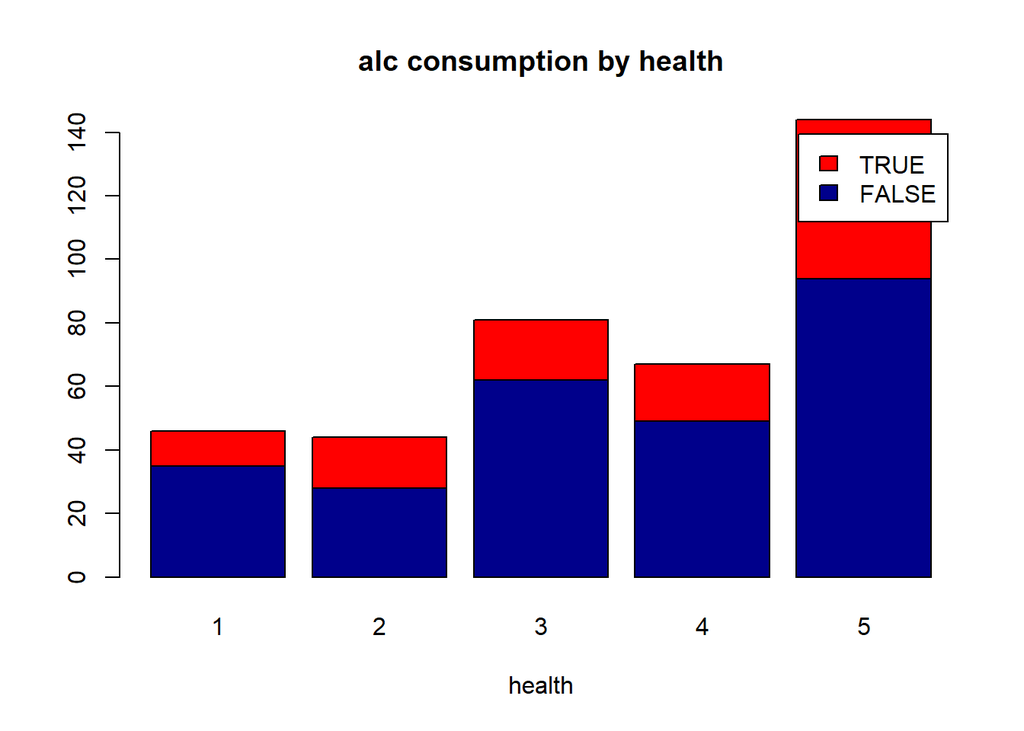

```r
counts <- table(mydata$high_use, mydata$health)
barplot(counts, main="alc consumption by health",
  xlab="health", col=c("darkblue", "red"),
    legend = rownames(counts))
```

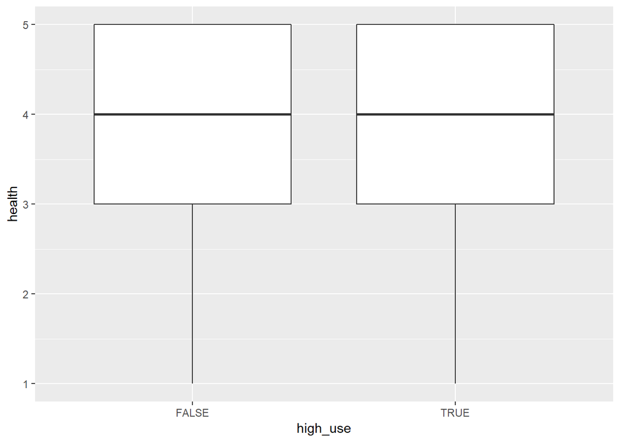

```r
library(ggplot2)
g1 <- ggplot(mydata, aes(x = high_use, y = health))

g1 + geom_boxplot() + ylab("health")
```

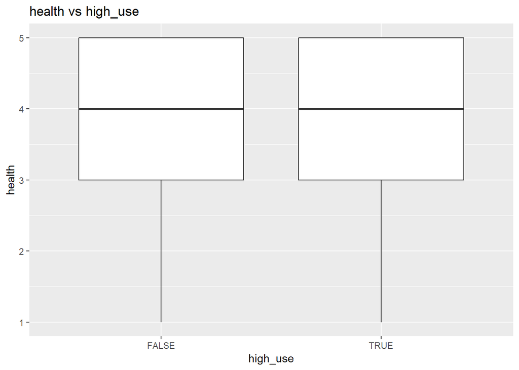

```r
g1 + geom_boxplot() + ggtitle("health vs high_use")
```

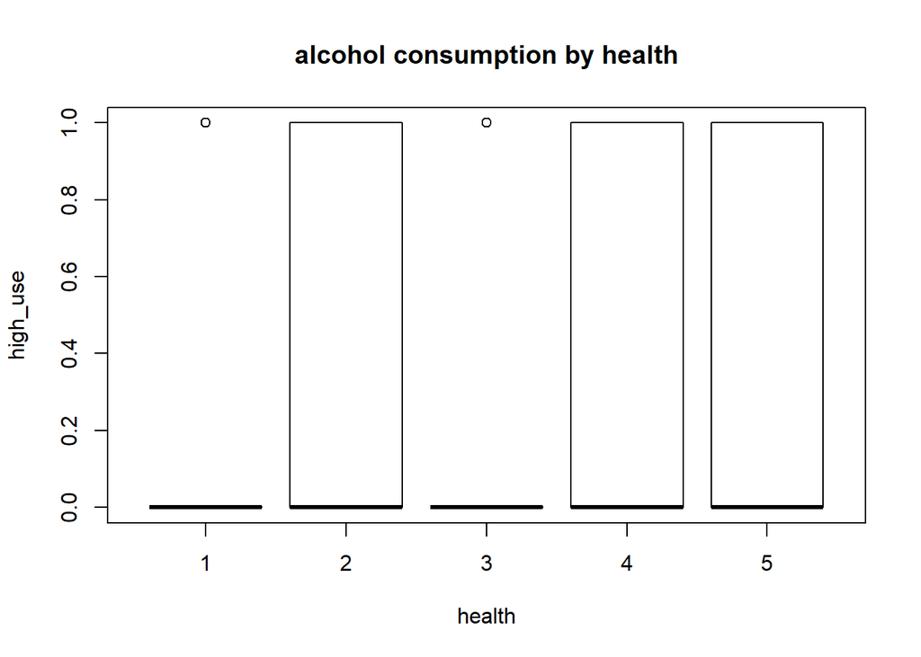

```r
boxplot(high_use ~ health, data=mydata, main="alcohol consumption by health",
    xlab="health", ylab="high_use")
```

alcohol consumption vs freetime

```r
attach(mydata)
cor(freetime, high_use)
```

```
## [1] 0.1508421
```

```r
mytable <- table(high_use, freetime)
addmargins(mytable)
```

```
##         freetime
## high_use   1   2   3   4   5 Sum
##    FALSE  15  49 113  70  21 268
##    TRUE    2  16  40  41  15 114
##    Sum    17  65 153 111  36 382
```

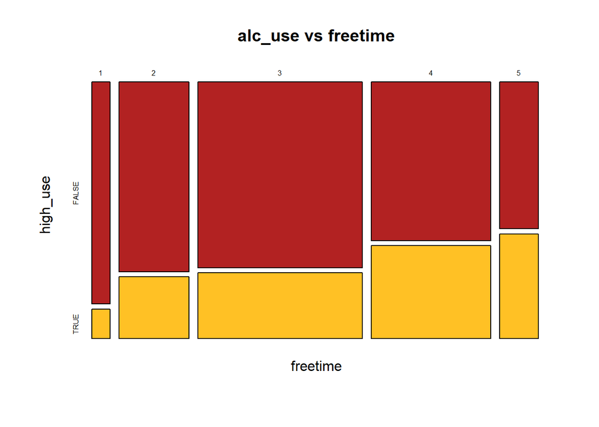

```r
mosaicplot( t(mytable), col = c("firebrick", "goldenrod1"), cex.axis = 0.5, main = "alc_use vs freetime")
```

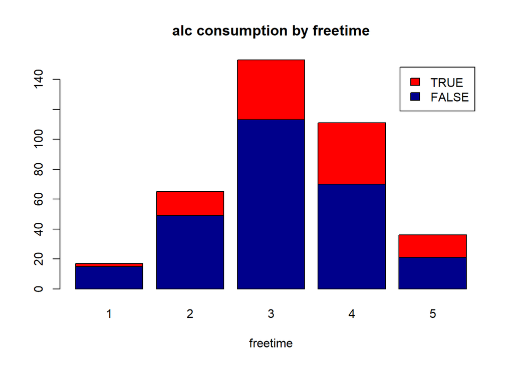

```r
counts <- table(mydata$high_use, mydata$freetime)
barplot(counts, main="alc consumption by freetime",
  xlab="freetime", col=c("darkblue", "red"),
    legend = rownames(counts))
```

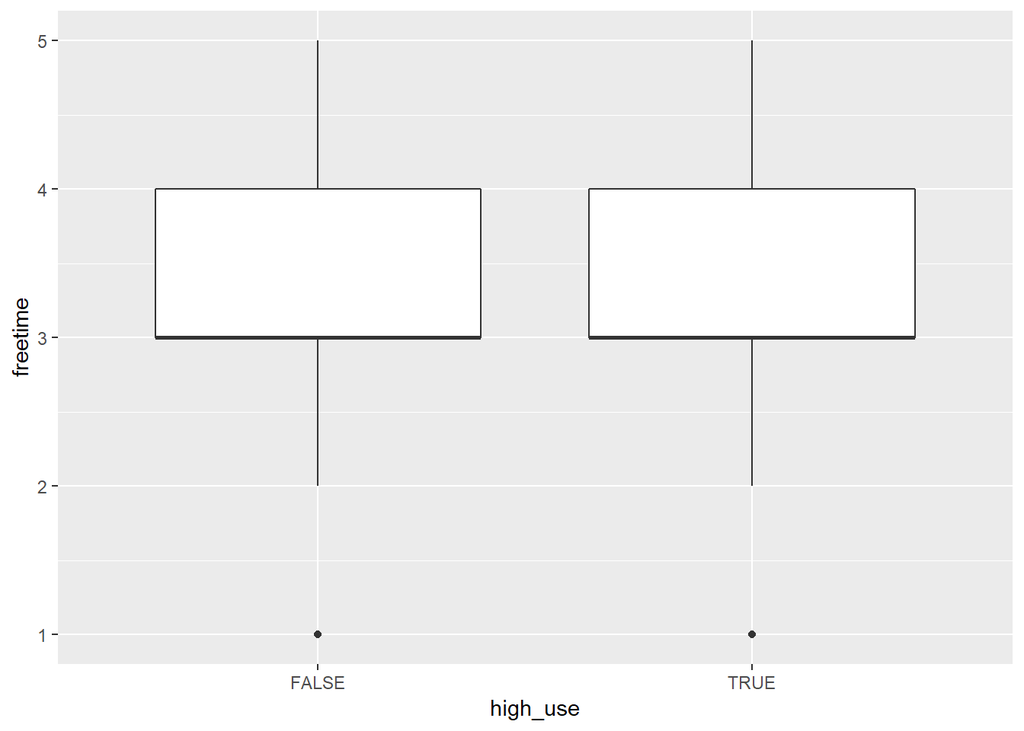

```r
library(ggplot2)
g1 <- ggplot(mydata, aes(x = high_use, y = freetime))

g1 + geom_boxplot() + ylab("freetime")
```

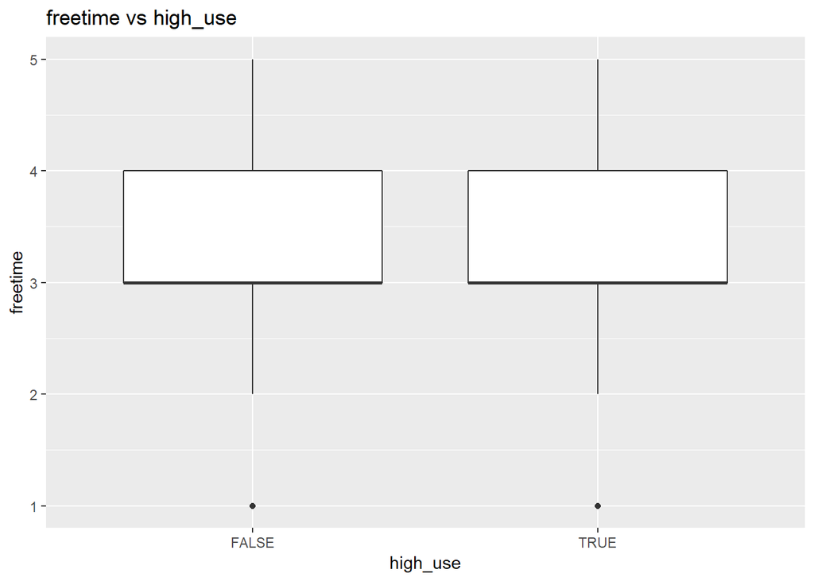

```r
g1 + geom_boxplot() + ggtitle("freetime vs high_use")
```

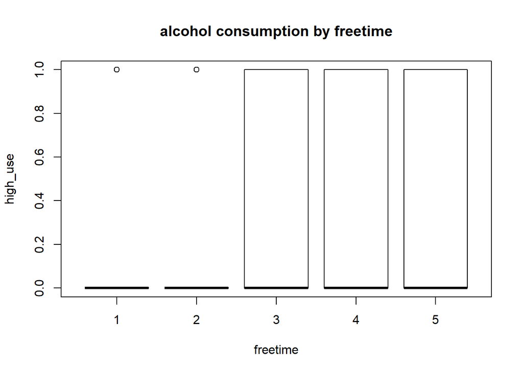

```r
boxplot(high_use ~ freetime, data=mydata, main="alcohol consumption by freetime",
    xlab="freetime", ylab="high_use")
```

5.Let,s now fit the logistic regression model.

```r
lr <- glm(high_use ~ age + failures + health + freetime, data = mydata, family = "binomial")
summary(lr)
```

```
##
## Call:
## glm(formula = high_use ~ age + failures + health + freetime,
##     family = "binomial", data = mydata)
##
## Deviance Residuals:
##     Min       1Q   Median       3Q      Max
## -1.5762  -0.8459  -0.7152   1.2772   1.9947
##
## Coefficients:
##             Estimate Std. Error z value Pr(>|z|)
## (Intercept) -5.22299    1.77664  -2.940  0.00328 **
## age          0.17751    0.10032   1.769  0.07683 .
## failures     0.42475    0.18992   2.236  0.02532 *
## health       0.07152    0.08464   0.845  0.39813
## freetime     0.32324    0.12060   2.680  0.00736 **
## ---
## Signif. codes:  0 '***' 0.001 '**' 0.01 '*' 0.05 '.' 0.1 ' ' 1
##
## (Dispersion parameter for binomial family taken to be 1)
##
##     Null deviance: 465.68  on 381  degrees of freedom
## Residual deviance: 445.66  on 377  degrees of freedom
## AIC: 455.66
##
## Number of Fisher Scoring iterations: 4
```

Deviance residuals, which are a measure of model fit. It shows the distribution of the deviance residuals for individual cases used in the model. From the model we can see that failures and freetime has the most significant relationship with alcohol use.

The logistic regression coefficients give the change in the log odds of the outcome for a one unit increase in the predictor variable. For every one unit change in age, the log odds of alcohol use increases by 0.17.

```r
coef(lr)
```

```
## (Intercept)         age    failures      health    freetime
## -5.22298692  0.17751209  0.42474936  0.07152038  0.32323750
```

```r
OR <- coef(lr) %>% exp
CI <- confint(lr) %>% exp
cbind(OR,CI)
```

```
##                      OR        2.5 %    97.5 %
## (Intercept) 0.005391202 0.0001553233 0.1672625
## age         1.194242493 0.9824070268 1.4570567
## failures    1.529207098 1.0558532403 2.2359959
## health      1.074140041 0.9113104069 1.2708920
## freetime    1.381593441 1.0939258330 1.7569297
```

from the odd ratios failures has the highest odd ratio(1.53) with 95% confidence interval(1.05 to 2.23) compare to freetime, age and heath. Which means for a one unit increase in failures, the odds of alcohol consumption increase by a factor of 1.53 and in 95% occasion it is true. Lets, remove age and health from the model and fil the model again

```r
lr2 <- glm(high_use ~ failures + freetime, data = mydata, family = "binomial")
summary(lr2)
```

```
##
## Call:
## glm(formula = high_use ~ failures + freetime, family = "binomial",
##     data = mydata)
##
## Deviance Residuals:
##     Min       1Q   Median       3Q      Max
## -1.6660  -0.8851  -0.7709   1.3429   1.9386
##
## Coefficients:
##             Estimate Std. Error z value Pr(>|z|)
## (Intercept)  -2.0395     0.4173  -4.887 1.02e-06 ***
## failures      0.5032     0.1845   2.727  0.00640 **
## freetime      0.3261     0.1198   2.723  0.00648 **
## ---
## Signif. codes:  0 '***' 0.001 '**' 0.01 '*' 0.05 '.' 0.1 ' ' 1
##
## (Dispersion parameter for binomial family taken to be 1)
##
##     Null deviance: 465.68  on 381  degrees of freedom
## Residual deviance: 449.32  on 379  degrees of freedom
## AIC: 455.32
##
## Number of Fisher Scoring iterations: 4
```

both failures and freetime is now statiscaly significant.

```r
coef(lr2)
```

```
## (Intercept)    failures    freetime
##  -2.0395331   0.5031849   0.3260915
```

```r
OR <- coef(lr2) %>% exp
CI <- confint(lr2) %>% exp
cbind(OR,CI)
```

```
##                    OR      2.5 %    97.5 %
## (Intercept) 0.1300894 0.05606577 0.2888379
## failures    1.6539806 1.15517975 2.3954959
## freetime    1.3855422 1.09890261 1.7591906
```

from the odd ratios at 95% CI we can see that failures has the highest odd ratio 1.65 and it improve from our previous model. so, we are now 95% sure, that failure affect alcohol consumption and for 1 unit change in failure, the odds of alcohol consumption increase by a factor of 1.65.

6. 2*2 cross tabulation of predictions versus the actual values

```r
probabilities <- predict(lr2, type = "response")
mydata <- mutate(mydata, probability = probabilities)
mydata<- mutate(mydata, prediction = probability > 0.5)
table(high_use = mydata$high_use, prediction = mydata$prediction)
```

```
##         prediction
## high_use FALSE TRUE
##    FALSE   260    8
##    TRUE    107    7
```

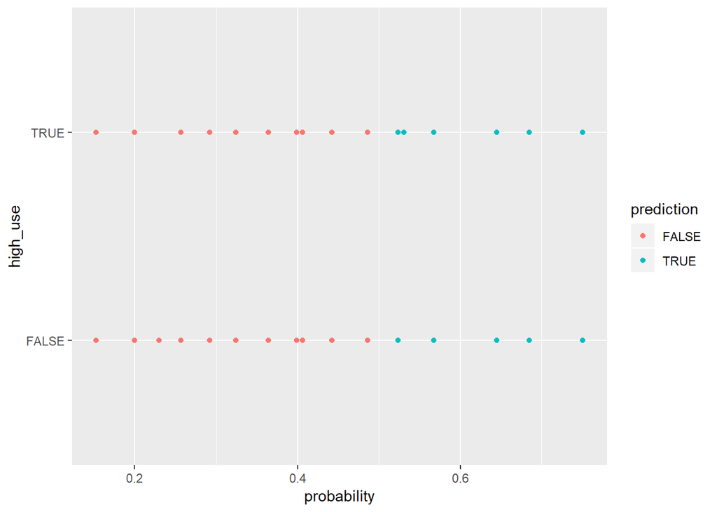

```r
library(dplyr); library(ggplot2)
g <- ggplot(mydata, aes(x = probability, y = high_use, col = prediction))
g + geom_point()
```

```r
round(table(high_use = mydata$high_use, prediction = mydata$prediction) %>% prop.table %>% addmargins, digits = 2)
```

```
##         prediction
## high_use FALSE TRUE  Sum
##    FALSE  0.68 0.02 0.70
##    TRUE   0.28 0.02 0.30
##    Sum    0.96 0.04 1.00
```

```r
loss_func <- function(class, prob) {
  n_wrong <- abs(class - prob) > 0.5
  mean(n_wrong)
}

loss_func(class = mydata$high_use, prob = mydata$probability)
```

```
## [1] 0.3010471
```

6. so , about 30% of observation incorrectly classified. while, the todal loss prediction is 100. comparative performance If, we would take low_use(FALSE for alcohol use is greater than 2) instead of high_use we would get 70% incorrect classified observation.
7. bonus

```r
library(boot)
cv <- cv.glm(data = mydata, cost = loss_func, glmfit = lr2, K = 10)
cv$delta[1]
```

```
## [1] 0.3089005
```

With 10-fold cross-validation the prediction error is around 0.30. which is higherer than in the data camp exercise.